# 자연언어처리 15주차 특강_lmer 및 afex를 사용한 선형혼합효과모형

고려대학교 일반대학원 심리학과

2022년 12월 16일 금요일 6-9시

# 1. 선형혼합효과모형의 소개

## (1) 반복측정 분산분석(repeated measures analysis of variance)의 한계

- 간접적 측정
  - 인지심리학 연구자들은 인간의 인지능력(구인[constructs])이 실험조건에 따라 어떻게 다른 양상을 나타내는지에 관심을 가짐.
  - 그러나 측정하고자 하는 구인은 직접 관찰이 불가능하므로 인간의 행동(예를 들면, 반응시간, 정확도)이나 생리적 반응(예를 들면, 뇌파반응) 같은 간접적 측정치를 사용하게 됨.
  - 이러한 간접적 측정치는 측정하고자 하는 구인과 무관한 변수들의 영향을 줄이기 위해 여러 시행(trials)에 걸쳐 측정.
- 참가자 내 설계(within subject design)
  - 같은 문항을 반복적으로 사용 X, 여러 문항을 사용. 가량, 단어재인과제 수행 시, 한 조건 안에서 여러 개의 단어 자극이 제시됨. 이는 학습효과나 단순노출 효과처럼 연구자가 원치 않는 효과를 방지하기 위함.
  - 참가자는 한 조건(예를 들면, 단어의 빈도)의 모든 층위(예를 들면, 고빈도, 중빈도, 저빈도)에 노출.
  - 장점: 적은 수의 참가자로 높은 검정력(power)을 얻을 수 있음.
  - 참가자의 반응은 실험의 조건, 참가자의 특성, 문항의 특성 등에 의해 설명될 수 있음. 이 가운데 우리가 원하는 것은 “실험의 조건”에 의해 설명되는 참가자의 반응임!
- 문항효과(item effect)
  - 종속변수를 측정하기 위해 사용된 문항의 특성이 참가자의 반응에 영향을 미치는 것을 의미.
  - 같은 조건일지라도 문항에 따라 참가자 반응의 정확도가 달라진다면, 문항의 난이도가 문항효과로 작용했음을 시사.
- 반복측정 분산분석
  - 매 시행에 대한 반응을 조건의 각 층위에서 평균을 낸 반응이 종속변수로 사용됨.
  - 참가자 내 설계에서 두 개의 조건이 각각 두 개의 층위를 가지고 있다면, (총 참가자 수) × 2 × 2 개의 크기를 가진 종속변수에 대해 반복측정 분석분석을 실시함으로써 각 조건의 통계적 유의성을 검정하게 됨. $\Rightarrow$ 여기서는 참가자의 개인차만이 연구자가 조작한 실험조건 이외에 참가자의 반응을 설명할 수 있는 유일한 요소가 됨. 하지만 문항의 특성(분산)이 참가자의 반응에 영향을 미칠 가능성은 무시됨.
  - 이러한 가정은 문항들의 평균값을 종속변수로 사용 시 문항이 설명하는 분산은 조건 내 시행 숙 증가할수록 작아질 것이라는 논리에 근거.
  - 그러나 유의미한 문항효과를 무시할 경우, 1종 및 2종 오류 모두 증가할 가능성이 높음.
  - 언어를 고정효과로 분석하는 오류(language-as-fixed-effect fallacy)
    - 문제점: 문항효과를 고려하지 않은 분석의 문제점 지적.
    - 대안
      - 참가자 분석(*F1*)과 문항분석(*F2*)가 모두 유의할 때만 조건 간 평균 차이가 유의미하다고 간주.
      - 언어심리학의 경우 다양한 언어항목을 사용. 한 참가자로부터 같은 조건으로 여러 개의 반응(문항)을 얻을 수도 있고, 반면에 한 문항으로부터 같은 조건으로 여러 개의 반응(참가자)을 얻을 수 있음.
      - 따라서 참가자 분석과 문항 분석을 병행하는 것이 반드시 필요함을 많은 학자들이 인지하게 됨.
      - 참가자 분산분석: 참가자를 무선(random) 변수로 간주하고 모든 참가자의 평균을 분석.
      - 문항 분산분석: 문항을 무선변수로 간주하고 모든 문항의 평균을 분석.
    - 한계점: 참가자 효과와 문항 효과를 하나의 모형에 포함할 수 없고, 문항효과 고려를 위해 *F1/F2*으로 나누어 각각 독립된 분석을 수행하는 번거로움을 감수해야 함.

## (2) 고정효과(fixed effects)와 무선효과(random effects)

- **혼합**효과모형(mixed effects models)이라고 불리는 이유: 고정효과와 무선효과를 동시에 지닌 모형이기 때문.
- 예시연구
  - 연구주제: 중국인 & 독일인 L2 영어 학습자의 영어 일치 형태소 처리.
  - 자극: 문법적 & 비문법적 일치 형태소를 지닌 문장.
  - 과제: 참가자가 컴퓨터에 제시되는 문장을 읽고 버튼을 누름.
  - 독립변수: 참가자의 L1(독일어 vs. 중국어), 문장의 문법성(정문 vs. 비문).
  - 종속변수: 문장에 대한 반응시간.
  - 가설: 영어 일치 형태소를 적절히 습득한 학습자는 정문보다 비문에 더 오래 반응할 것이다.

### 1) 고정효과

- 소개
  - 실험에 상관없이 영향을 미치는 모집단 층위의 효과.
  - 전형적으로 연구의 독립변수(조건)가 여기에 해당. 이들은 모집단에서 어떤 참여자와 문항을 표집했든 예측 가능한 방식으로 작동할 것.
- 문장의 문법성은 고정효과
  - 문장의 문법성과 반응시간 사이에는 평균적 관계/트렌드(average relationship/trends)가 있을 것으로 예측하기 때문.
  - 이러한 관계는 다른 참가자와 문항의 표본을 대상으로 같은 실험을 시행해도 똑같이 재현될 것.

### 2) 무선효과

- 소개
  - 표본의 무작위 변이(random variation).
  - 고정효과의 트렌드가 참여자 또는 문항마다 다르게 나타나는 정도.
  - 특정 참가자 또는 문항이 평균적인 트렌드와 다르다는 사실을 설명하기 위해 모형에 포함됨.
  - 반드시 범주변수여야 함.
- 참가자와 문항은 무선효과
  - 참가자
    - 중국인 학습자가 독인일 학습자보다 평균적으로 더 느린 반응을 나타냈다고 가정. $\Rightarrow$ L1 배경이 영어 일치 형태소의 처리에 영향을 미친다고 결론 내릴 수도 있음.
    - 그러나 학습자가 속한 교실의 군집을 고려에 넣지 않았다면 이는 때 이른 결론일 수 있음. 모수통계 검정의 기본가정은 개별 관찰값이 서로 **독립적**이어야 한다는 것! 그러나 같은 교실에 속한 참가자의 관찰값은 완벽하게 독립적일 수 없음. 만약 한 중국인 학습자 교실의 선생님이 특별히 훌륭해서 목표문법을 잘 배웠다면, 그 교실의 중국인 학습자만 느린 반응을 나타내고 다른 교실의 중국인 학습자는 독일인 학습자와 비슷한 양상을 나타낼 것.
    - 교실 간 무작위 변이를 고려에 넣는다면 L1 배경의 역할이 영어 일치 형태소 처리에 미치는 영향에 대한 결론을 확신할 수 없게 됨.
    - 교실 내 참가자도 마찬가지임. 참가자마다 가족의 (영어) 교육수준이 다를 것. 이때 교실은 가족이라는 무작위 변이의 원천 속에 끼워넣을 수 없지만, 가족은 교실 속에 끼워넣을 수 있음(교실이 가족보다 훨씬 큰 단위이므로).

### A. 무선 절편(random intercept)

- 개별 참가자의 평균 반응시간
  - 개별 참가자는 전반적인 반응시간 자체가 무작위적으로 다를 것.
  - 예시
    - 정신을 집중하고 있는 참가자들은 평균적으로 비교적 빠르게 응답하지만, 전날 과로한 참가자들은 평균적으로 비교적 느리게 응답할 것임.
    - 어떤 참가자는 비문이나 정문이나 비슷한 반응시간을 나타내지만, 다른 참가자는 비문보다 정문에 더 느리게 반응할 수도 있음.
- 무선 절편: 각 참가자의 평균 반응시간(문법성에 관계없이) 차이.

### B. 무선 기울기(random slope)

- 무선 기울기
  - 개별 참가자 간 문법성에 대한 민감도의 차이: 어떤 참가자는 문법성에 매우 민감하지만, 다른 참가자는 문법성에 매우 둔감할 수 있음,
  - 위와 같은 경향은 우리가 가정하는 모형에 의해 설명되지 않는 의존성으로 이어질 가능성이 높음. L1 배경이 아니라, 참가자가 기본적으로 문법성에 대해 가지고 있는 민감도만으로 반응시간을 설명할 수 있게 됨!

**[그림 1] 고정효과만 지닌 회귀선**

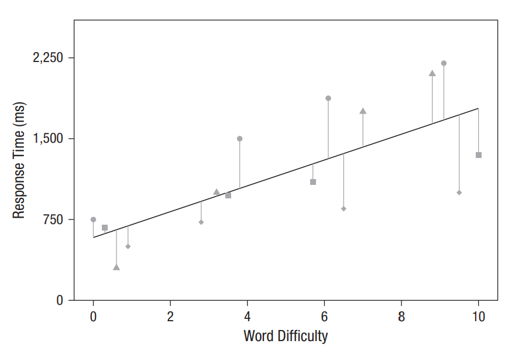

**[그림 2] 무선 절편만 지닌 혼합효과 회귀선**

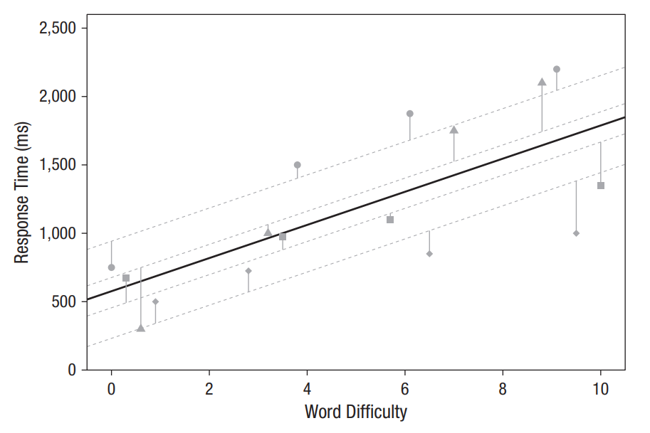

**[그림 3] 무선 절편과 무선 기울기를 지닌 혼합효과 회귀선**

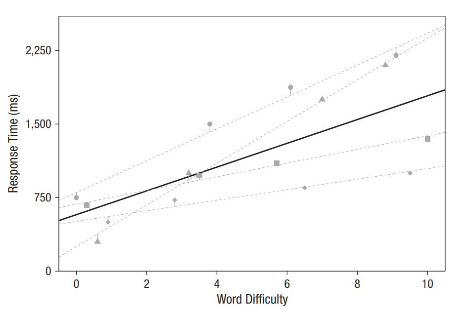

# 2. 선형혼합효과모형의 통계적 가정

## (1) 통계적 가정

- 선형성(linearity).
- 등분산성(homoscedasticity): 잔차(오차)의 분산이 예측변수의 각 관찰값마다 동일한 값을 나타내야 함.
- 독립성(independence): 관찰값은 모두 독립적이어야 함. 특정 관찰값이 다른 관찰값에 의존하지 않아야 함. 가장 중요!
- 정규성(nomarlity).

**[그림 4] 등분산성의 개념**

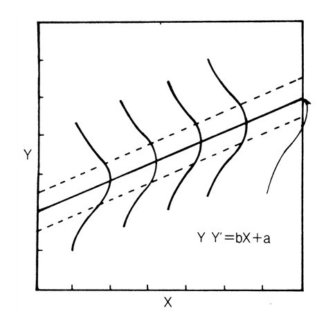

## (2) 통계적 가정 확인 방법

- 모형의 선형성, 잔차/오차의 정규성, 등분산성 진단
  - R의 내장함수 `plot` 사용.
  - **ggfortify** 패키지의 함수 `autoplot` 사용.
- `which` 논항의 선택지 설명명
  1. 모형을 통해 예측된 값(*x*축)과 잔차(*y*축) 플롯. 선형성과 등분산성 점검에 사용.
  2. 표준화된 잔차의 QQ-플롯. 잔차의 정규성 점검에 사용.
  3. 모형을 통해 예측된 값(*x*축)과 표준화된 잔차의 제곱근(*y*축) 플롯. 1번 플롯의 변종으로, 선형성과 등분산성 점검에 사용.
  4. 관찰값 번호(*x*축)와 Cook의 거리(*y*축) 플롯. 모형에 영향을 미치는 관찰값(Cook의 거리가 큰 관찰값) 파악에 도움을 줌.
  5. 개별 관찰값의 leverage 값(*x*축)과 표준화된 잔차(*y*축) 플롯. 모형에 영향을 미치는 관찰값과 극단값 파악에 도움을 줌. leverage 값은 개별 관찰값이 모형에 미치는 영향력을 가리키며, Cook의 거리와도 관련이 있음.
  6. 개별 관찰값의 leverage 값(*x*축)과 그에 대응하는 Cook의 거리(*y*축) 플롯.모형에 영향을 미치는 관찰값과 극단값 파악에 도움을 줌.

> autoplot(모형 이름, which = 원하는 플롯의 수/번호) *OR* plot(모형 이름, which = 원하는 플롯의 수/번호)

**[그림 5] 잔차 플롯(1번 플롯)의 사례**

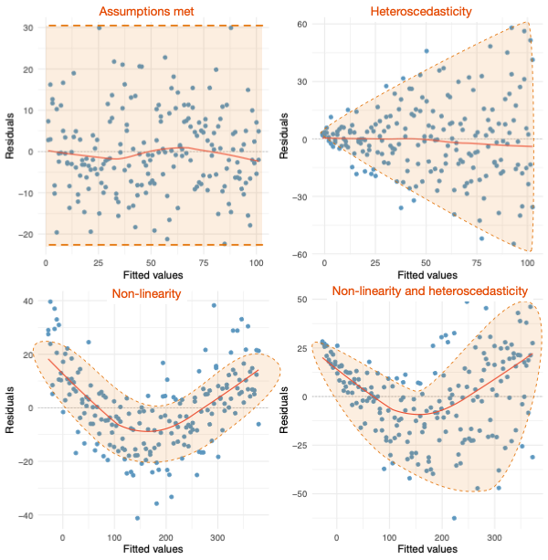

```r
# full_lm 진단하기(1-6번 플롯 모두 그려보기).
library(tidyverse)
library(ggfortify)
library(afex)
```

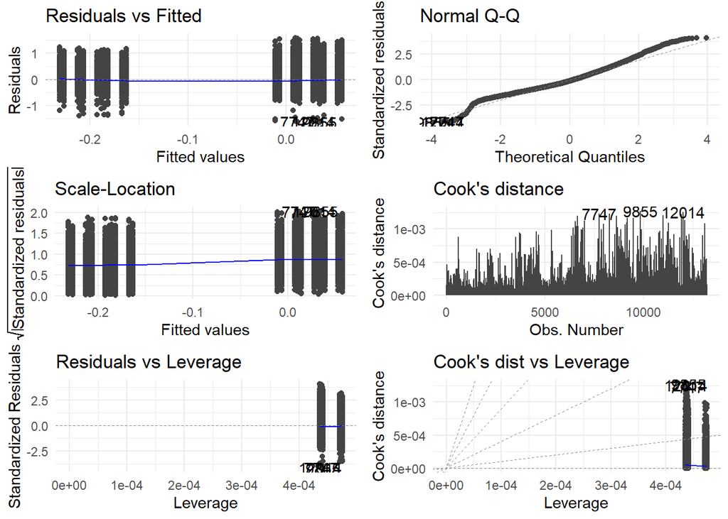

```r
data(fhch2010)

full_lm <- lm(log_rt ~ task + density + frequency + length, data = fhch2010, na.action = na.exclude)
autoplot(full_lm, which = 1:6) +
  theme_minimal() # 플롯 배경 간소화하기.
```

- 모형에 영향을 미치는 관찰값과 극단값 파악하기
  - **broom** 패키지의 `augment` 함수를 통해 Cook의 거리와 표준화된 잔차를 구할 수 있음.
  - 표준화된 잔차: 95%는 절대값 1.96 내에, 99%는 2.5 내에 있어야 함. 3 이상은 극단값으로 간주.
  - Cook의 거리: 평균의 3배 이상, 1 이상이면 극단값으로 간주.
  - 극단값들을 제거한 뒤 모형 내 값들이 어떻게 그리고 얼마나 변화하는지 살펴볼 것.

```r
# augment 함수를 통해 관찰값마다 Cook의 거리와 표준화된 잔차를 구함.
library(broom)
full_rsd <- full_lm %>%
  augment(., data = fhch2010) %>%
  tibble::rowid_to_column(var = "case_no") # case_no라는 칼럼을 만들어 행 번호 값을 거기에 넣겠다는 뜻.

# 표준화된 잔차를 바탕으로 극단값 파악하기.
full_rsd %>%
  filter(abs(.std.resid) >= 1.96) %>%
  dplyr::select(case_no, .std.resid, .resid) %>%
  arrange(.std.resid)
```

```
## # A tibble: 627 × 3
##    case_no .std.resid .resid
##      <int>      <dbl>  <dbl>
##  1    9855      -4.17  -1.63
##  2   12014      -4.15  -1.62
##  3    7747      -4.11  -1.61
##  4    8283      -4.11  -1.61
##  5   11924      -4.10  -1.60
##  6    6665      -4.05  -1.58
##  7   11272      -3.86  -1.51
##  8   13112      -3.86  -1.51
##  9    6602      -3.79  -1.48
## 10    6695      -3.79  -1.48
## # … with 617 more rows
```

```r
# Cook의 거리를 바탕으로 극단값 파악하기(1 이상인 값 찾기).
full_rsd %>%
  arrange(desc(.cooksd)) %>%
  dplyr::select(case_no, .cooksd)
```

```
## # A tibble: 13,222 × 2
##    case_no .cooksd
##      <int>   <dbl>
##  1    9855 0.00128
##  2   12014 0.00125
##  3    7747 0.00123
##  4    8283 0.00123
##  5   11924 0.00122
##  6   11005 0.00121
##  7    6665 0.00120
##  8    8636 0.00120
##  9    9484 0.00117
## 10    9196 0.00117
## # … with 13,212 more rows
```

# 3. 선형혼합효과모형분석 실습

## (1) 종속변수가 연속변수인 경우: 선형혼합효과모형

### 1) 준비사항

```r
library(afex) # 혼합효과모형 수행.
library(lmerTest) # 혼합효과모형 수행.
```

```r
library(emmeans) # 후속검정 수행.
library(sjPlot) # 혼합효과모형 분석 결과 html로 반출.
library(broom.mixed) # 혼합효과모형 분석 결과 티블로 만들기.
```

### 1) 예시 데이터셋

```r
data(fhch2010) # 데이터셋 로딩하기.
# 데이터셋에서 틀린 문항 제거하기.
fhch <- fhch2010 %>%
  as_tibble() %>%
  filter(correct == T)
str(fhch2010) # 데이터의 구조 살펴보기.
```

```
## 'data.frame':    13222 obs. of  10 variables:
##  $ id       : Factor w/ 45 levels "N1","N12","N13",..: 1 1 1 1 1 1 1 1 1 1 ...
##  $ task     : Factor w/ 2 levels "naming","lexdec": 1 1 1 1 1 1 1 1 1 1 ...
##  $ stimulus : Factor w/ 2 levels "word","nonword": 1 1 1 2 2 1 2 2 1 2 ...
##  $ density  : Factor w/ 2 levels "low","high": 2 1 1 2 1 2 1 1 1 1 ...
##  $ frequency: Factor w/ 2 levels "low","high": 1 2 2 2 2 2 1 2 1 2 ...
##  $ length   : Factor w/ 3 levels "4","5","6": 3 3 2 2 1 1 3 2 1 3 ...
##  $ item     : Factor w/ 600 levels "abide","acts",..: 363 121 202 525 580 135 42 368 227 141 ...
##  $ rt       : num  1.091 0.876 0.71 1.21 0.843 ...
##  $ log_rt   : num  0.0871 -0.1324 -0.3425 0.1906 -0.1708 ...
##  $ correct  : logi  TRUE TRUE TRUE TRUE TRUE TRUE ...
```

- 참가자가 조건당 몇 명 있는지 확인하기.

```r
fhch %>%
  group_by(id) %>%
  summarise(task = first(task)) %>% # ID별로 task를 하나씩만 추출.
  ungroup() %>%
  group_by(task) %>%
  summarise(n = n())
```

```
## # A tibble: 2 × 2
##   task       n
##   <fct>  <int>
## 1 naming    20
## 2 lexdec    25
```

- 참가자당 최대, 최소, 평균 몇 개의 문항을 풀었는지 확인하기.

```r
fhch %>% group_by(id, stimulus) %>%
  summarise(items = n_distinct(item)) %>% # n_distinct() = length(unique())
  ungroup() %>%
  group_by(stimulus) %>%
  summarise(min = min(items),
            max = max(items),
            mean = mean(items))
```

[output not shown]

```
## # A tibble: 2 × 4
##   stimulus   min   max  mean
##   <fct>    <int> <int> <dbl>
## 1 word       135   150  145.
## 2 nonword    124   150  143.
```

### 2) 통계적 가정 확인

- 정규성 검정: 분석을 시행하기 전 종속변수가 정규분포를 띠는지 확인해야 함.
- 자료변형: `rt`와 `log_rt`를 비교하기 위해 자료변형 후 히스토그램으로 정규분포 여부 확인하기.

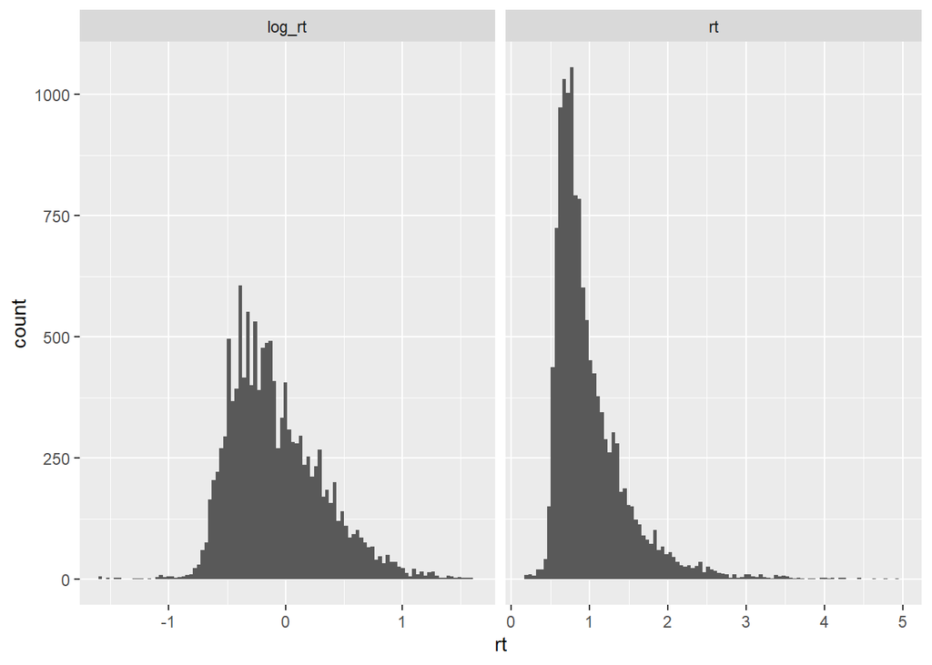

```r
# rt와 log_rt를 하나의 열에 몰아넣기.
fhch_long <- fhch %>%
  pivot_longer(cols = c(rt, log_rt), names_to = "rt_type", values_to = "rt")

# ggplot으로 히스토그램 그리기.
ggplot(fhch_long, aes(rt)) +
  geom_histogram(bins = 100) +
  facet_wrap(vars(rt_type), scales = "free_x")
```

### 3) 통계분석

#### A. 기술통계 분석

- 참가자 간 변수: `task`(`naming` vs. `lexdec`)
- 참가자 내 변수: `stimulus`(`word` vs. `nonword`), `density`(`low` vs. `high`), `frequency`(`low` vs. `high`).
- 결과예상을 위해 데이터를 시각적으로 탐색하기
  - 통계적 검정 결과가 예상과 극적으로 불일치한다면, 이는 모종의 오류가 발생했음을 의미.
  - 1단계: 참여자별로 데이터를 종합하여 플로팅해볼 것. $\Rightarrow$ 원자료(raw data)를 배경에 플로팅할 예정. 반투명 플로팅을 위해 **ggbeeswarm** 패키지의 `geom_quasirandom(alpha = 0.5)` 함수를 사용. 그 위에 박스플롯(box plot), 평균 및 표준오차를 추가.
  - 2단계: 문항별로 데이터를 종합하여 플로팅해볼 것. 과정은 1단계와 동일.

```r
# 참여자(id)와 각종 독립변수를 바탕으로 그루핑한 뒤 평균 구하기.
agg_p <- fhch %>%
  group_by(id, task, stimulus, density, frequency) %>%
  summarise(mean = mean(log_rt)) %>%
  ungroup()
```

[output not shown]

```
## No summary function supplied, defaulting to `mean_se()`
## No summary function supplied, defaulting to `mean_se()`
## No summary function supplied, defaulting to `mean_se()`
## No summary function supplied, defaulting to `mean_se()`
```

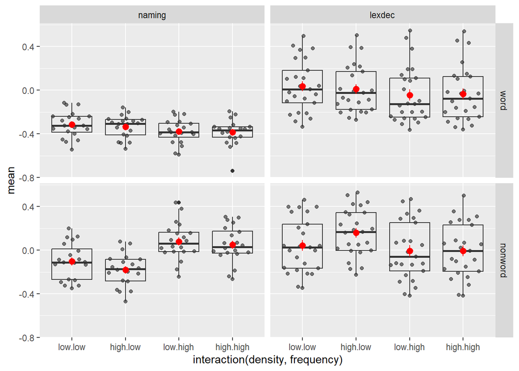

```r
# 참여자별 기술통계 분석 결과 시각화하기.
library(ggbeeswarm)
ggplot(agg_p, aes(x = interaction(density,frequency), y = mean)) +
  geom_quasirandom(alpha = 0.5) +
  geom_boxplot(fill = "transparent") +
  stat_summary(colour = "red") +
  facet_grid(cols = vars(task), rows = vars(stimulus))
```

```r
# 문항(item)과 각종 독립변수를 바탕으로 그루핑한 뒤 평균 구하기.
agg_i <- fhch %>% group_by(item, task, stimulus, density, frequency) %>%
  summarise(mean = mean(log_rt)) %>%
  ungroup()
```

[output not shown]

```
## No summary function supplied, defaulting to `mean_se()`
## No summary function supplied, defaulting to `mean_se()`
## No summary function supplied, defaulting to `mean_se()`
## No summary function supplied, defaulting to `mean_se()`
```

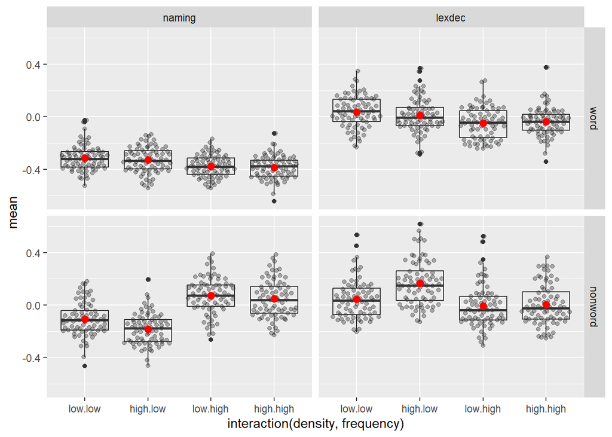

```r
# 문항별 기술통계 분석 결과 시각화하기.
ggplot(agg_i, aes(x = interaction(density,frequency), y = mean)) +
  geom_quasirandom(alpha = 0.3) +
  geom_boxplot(fill = "transparent") +
  stat_summary(colour = "red") +
  facet_grid(cols = vars(task), rows = vars(stimulus))
```

- 결과해석: 두 개의 플롯이 유사한 패턴을 나타냄.
  - 적어도 이름 대기(`naming`) 과제에서는 `nonwords`에 대한 응답이 `words`에 대한 응답보다 느렸음.
  - 어휘판단과제(`lexdec`) 응답은 이름 대기 과제 응답보다 느리며, 특히 이는 `word` 조건에서 두드러짐.
  - `nonword`와 `naming` 조건에서는 `frequency`의 효과가 분명하게 나타남. `low` 빈도 단어보다 `high` 빈도 단어에서 더 반응시간이 느려짐.
  - `word`와 `naming` 조건에서는 `frequency` 패턴이 상술한 것과 반대의 패턴을 나타냄. `low` 빈도 단어보다 `high` 빈도 단어다 더 반응시간이 빨라짐.
  - `density` 변수는 `nonword` 어휘판단과제 조건을 제외하고는 효과가 없는 것으로 보임.

#### B. 모형 수립하기

**[그림 6] lmer의 무선효과 1**

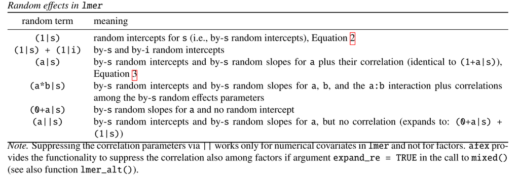

**[그림 7] lmer의 무선효과 2**

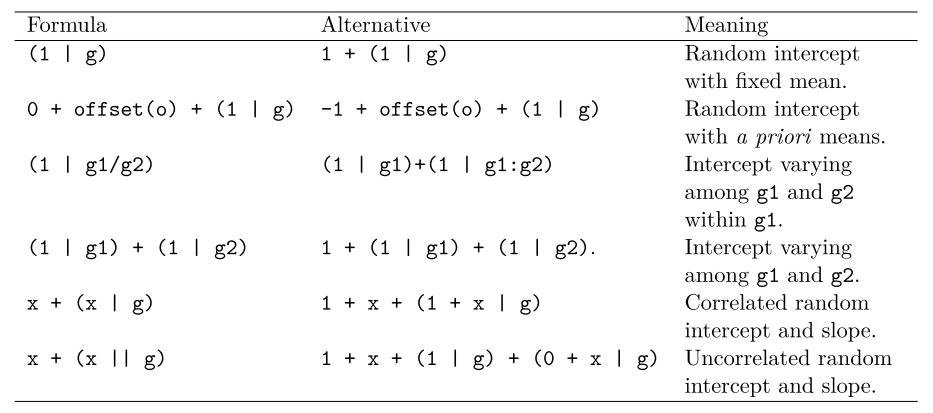

- 무작위 변이 생성 요인 파악하기
  - 혼합모형을 설정하려면 어떤 요인이 무선변이를 생성하는 요인인지를 파악하는 것이 중요.
  - 무선효과
    - 참여자: `id`.
    - 문항: `item`
  - 고정효과
    - 참가자 내 변수: `stimulus`, `density`, `frequency`.
    - 참가자 간 변수: `task`.
- 모든 무선효과와 고정효과를 다 갖춘 최대모형(maximal model)에서 시작하기(Barr, Levy, Scheepers, & Tily, 2013)
  - 참가자별 `stimulus`, `density`, `frequency` 무선 기울기 및 무선 절편.
  - 참가자별 `stimulus`, `density`, `frequency` 간 상호작용 무선 기울기 및 무선 절편.
  - 문항별 `task` 무선 기울기 및 무선 절편.
- 복잡한 무선효과 구조를 지닌 최대모형은 성공적으로 수렴되지 않는 것이 일반적.
- `“boundary (singular) fit”`
  - 상기 경고가 나온다면 해당 모형은 사용해선 안 됨.
  - 모형에 매개변수가 너무 많아서 성공적으로 수렴되지 않았음을 가리킴.
  - 현재 주어진 데이터에 비해 너무 많은 무선효과 매개변수를 가지고 있음을 가리킴.
- 최대모형이 수렴되지 않는다면 모형을 한 단계씩 축소시켜나갈 것. 축소된 모형이 경고 없이 수렴된다면 해당 모형을 취할 것.
- 모형축소의 일반적 단계
  1. 무선 절편과 무선 기울기 간 상관관계 모두 취하기.
  2. 문항별 무선효과 간 상관관계(여기선 무선 절편과 `task` 무선 기울기 간의 상관관계) 제거하기.
  3. 참가자별 무선효과 간 상관관계(여기선 무선 기울기 간의 상관관계 및 무선 기울기와 무선 절편 간의 상관관계) 제거하기.
- *p*-값 계산 방법 결정하기
  - `method = "KR"`: Kenward-Roger 방법. 복잡한 모형일수록 RAM 용량을 많이 필요로 함.
  - `method = "S"`: Satterthwaite 방법. Kenward-Roger와 유사한 수준으로 유형 1 오류 통제해주면서도 용량을 덜 사용함. 해당 방법이 기본값으로 설정되어 있음.

#### C. 최종 모형 찾기

- `||`: 무선효과 간 상관관계 억제용 코드. 단, 이때 연속변수가 아닌 범주변수가 투입될 경우 `expand_re = TRUE` 논항을 반드시 추가해야 함. 이는 **afex** 패키지의 `mixed()` 함수에서만 가능하므로 **lmerTest**의 `lmer` 함수에서는 적용하지 말 것.
- 범주변수가 상호작용에 포함될 경우, R 기본값인 `contr.treatment`이 아닌 `contr.sum` 대조 코딩을 사용함.
- `lmerControl`
  - `maxfun = 1e+06`: *p-값 계산이 채 끝나지 않았는데 모형추정이 종료되는 것을 막기 위해 `maxfun`을 큰 수로 설정.
  - `calc.derivs = FALSE`: 계산에 필요한 용량을 줄이는 데 효과가 있음.
  - `freeman_models.rda`: 모형추정에 시간이 오래 걸리므로, 결과를 빨리 확인하고 싶다면 `freeman_models.rda`를 로딩할 것.
- 첫 번째 모형(최대모형) 추정하기.

```r
m1s <- mixed(log_rt ~ task*stimulus*density*frequency +
               (stimulus*density*frequency|id)+
               (task|item), data = fhch,
             control = lmerControl(calc.derivs = FALSE, optCtrl = list(maxfun = 1e+06)), expand_re = TRUE)
```

- 두 번째 모형 추정하기: 문항별 무선 기울기와 무선 절편 간 상관관계 제거.

```r
m2s <- mixed(log_rt ~ task*stimulus*density*frequency +
               (stimulus*density*frequency|id)+
               (task||item), fhch,
             control = lmerControl(calc.derivs = FALSE, optCtrl = list(maxfun = 1e+06)), expand_re = TRUE)
```

- 세 번째 모형 추정하기: 참여자별 무선 기울기와 무선 절편 간 상관관계 제거.

```r
m3s <- mixed(log_rt ~ task*stimulus*density*frequency +
               (stimulus*density*frequency||id)+
               (task|item), fhch,
             control = lmerControl(calc.derivs = FALSE, optCtrl = list(maxfun = 1e+06)), expand_re = TRUE)
```

- 네 번째 모형 추정하기: 참여자별 & 문항별 무선 기울기와 무선 절편 간 상관관계 제거하기.

```r
m4s <- mixed(log_rt ~ task*stimulus*density*frequency +
               (stimulus*density*frequency||id)+
               (task||item), fhch,
             control = lmerControl(calc.derivs = FALSE, optCtrl = list(maxfun = 1e+06)), expand_re = TRUE)
```

- 중간점검
  - 12,960개의 비교적 많은 관찰값에도 불구하고, 참여자별 7개의 무선 기울기와 문항별 한 개의 무선 기울기를 가지고는 성공적 추정이 불가능한 상태.
  - 이는 상관관계를 모두 제거했음에도 마찬가지.
  - 사실 본 데이터셋은 각 범주변수가 2개의 층위만을 지니고 있어 그나마 행운. 범주변수의 층위가 늘어난다면 무선효과 매개변수도 같이 늘어날 것.
- 무선효과 추정치 파악
  - 다음 단계로 넘어가기 전에 우선 무선효과 추정치를 살펴보기.
  - `summary(model)$varcor`: 모형의 무선효과 추정치의 표준편차 확인.

```r
# m4s 모형의 무선효과 추정치 표준오차 확인.
summary(m4s)$varcor
```

[output not shown]

- 결과해석
  - 2원 상호작용의 무선 기울기는 모두 표준편차가 0임. 하지만 3원 상호작용의 무선 기울기의 표준편차는 0.0077923.
  - 그러나 3원 상호작용을 유지하면서 2원 상호작용만 제거할 수는 없으므로, 3원 상호작용을 먼저 제거하기로 함.

```r
m5s <- mixed(log_rt ~ task*stimulus*density*frequency +
               ((stimulus+density+frequency)^2||id)+ # 2원 상호작용 유지.
               (task||item), fhch,
             control = lmerControl(calc.derivs = FALSE, optCtrl = list(maxfun = 1e+06)), expand_re = TRUE)
summary(m5s)$varcor
```

[output not shown]

- 결과해석
  - 예상한 대로 boundary (singular) fit 경고가 나옴.
  - 참여자별 무선 기울기 2원 상호작용은 모두 표준편차가 여전히 0임.
  - 이제 2원 상호작용도 제거하기.

```r
m6s <- mixed(log_rt ~ task*stimulus*density*frequency +
               (stimulus+density+frequency||id)+
               (task||item), fhch,
             control = lmerControl(calc.derivs = FALSE, optCtrl = list(maxfun = 1e+06)), expand_re = TRUE)
summary(m6s)$varcor
```

[output not shown]

- 결과해석
  - 여전히 boundary (singular) fit 경고가 나옴.
  - `density` 변수의 표준편차가 0임.
  - 이제 `density` 무선 기울기 제거하기.

```r
m7s <- mixed(log_rt ~ task*stimulus*density*frequency +
               (stimulus+frequency||id)+
               (task||item), fhch,
             control = lmerControl(calc.derivs = FALSE, optCtrl = list(maxfun = 1e+06)), expand_re = TRUE)
```

- 결과해석
  - 더 이상 boundary (singular) fit 경고가 나오지 않음. 이게 우리의 최종모형일까?
  - 이에 대한 결정을 내리기 전에, 아무 문제 없이 상관관계 term을 추가할 수 있을지 확인해볼 것.
  - 참여자별 및 문항별 무선 기울기와 무선 절편 간의 상관관계 term을 추가해보기.

```r
m8s <- mixed(log_rt ~ task*stimulus*density*frequency +
               (stimulus+frequency|id)+
               (task|item), fhch,
             control = lmerControl(calc.derivs = FALSE, optCtrl = list(maxfun = 1e+06)), expand_re = TRUE)
```

```
## Contrasts set to contr.sum for the following variables: task, stimulus, density, frequency, id, item
```

```r
save(m8s, file="m8s.rda")

m8s_1 <- lmer(log_rt ~ task*stimulus*density*frequency +
               (stimulus+frequency|id)+
               (task|item), data= fhch,  na.action = na.omit,
             control = lmerControl(calc.derivs = FALSE, optCtrl = list(maxfun = 1e+06)))
save(m8s_1, file="m8s_1.rda")

all_fit(m8s_1)
```

[output not shown]

[output not shown]

[output not shown]

[output not shown]

[output not shown]

[output not shown]

[output not shown]

```
## $bobyqa.
## Linear mixed model fit by REML ['lmerModLmerTest']
## Formula: log_rt ~ task * stimulus * density * frequency + (stimulus +
##     frequency | id) + (task | item)
##    Data: fhch
## REML criterion at convergence: 6620.946
## Random effects:
##  Groups   Name            Std.Dev. Corr
##  item     (Intercept)     0.05053
##           tasklexdec      0.11130  -0.51
##  id       (Intercept)     0.18039
##           stimulusnonword 0.08946   0.00
##           frequencyhigh   0.03608   0.45 -0.21
##  Residual                 0.30037
## Number of obs: 12960, groups:  item, 600; id, 45
## Fixed Effects:
##                                          (Intercept)
##                                            -0.313473
##                                           tasklexdec
##                                             0.350870
##                                      stimulusnonword
##                                             0.209284
##                                          densityhigh
##                                            -0.019714
##                                        frequencyhigh
##                                            -0.064264
##                           tasklexdec:stimulusnonword
##                                            -0.201340
##                               tasklexdec:densityhigh
##                                            -0.008583
##                          stimulusnonword:densityhigh
##                                            -0.057830
##                             tasklexdec:frequencyhigh
##                                            -0.018506
##                        stimulusnonword:frequencyhigh
##                                             0.247208
##                            densityhigh:frequencyhigh
##                                             0.010984
##               tasklexdec:stimulusnonword:densityhigh
##                                             0.204666
```

[output cut: 243 more lines]

[output not shown]

```r
# afex 객체 분석 결과를 티블 형식으로 정리하기.
m8s.tidy <- summary(m8s)$coefficients %>%
  as.data.frame() %>%
  rownames_to_column() %>%
  as_tibble() %>%
  rename(variable = rowname)

# sjPlot 패키지의 tab_df() 함수를 사용하여 분석결과를 데이터프레임 형식으로 html로 반출하기.
tab_df(m8s.tidy, digits = 5)
```

| variable | Estimate | Std..Error | df | t.value | Pr…t.. |
| --- | --- | --- | --- | --- | --- |
| (Intercept) | -0.08788 | 0.02924 | 43.44982 | -3.00531 | 0.00439 |
| task1 | -0.10821 | 0.02925 | 43.50761 | -3.69927 | 0.00060 |
| stimulus1 | -0.09270 | 0.00754 | 50.51956 | -12.29986 | 0.00000 |
| density1 | 0.00205 | 0.00343 | 584.76945 | 0.59732 | 0.55053 |
| frequency1 | 0.00327 | 0.00437 | 70.13791 | 0.74814 | 0.45688 |
| task1:stimulus1 | -0.06393 | 0.00757 | 51.47661 | -8.43954 | 0.00000 |
| task1:density1 | 0.01487 | 0.00351 | 578.61039 | 4.23385 | 0.00003 |
| stimulus1:density1 | 0.00374 | 0.00343 | 584.77896 | 1.08920 | 0.27651 |
| task1:frequency1 | -0.04033 | 0.00444 | 74.05941 | -9.09242 | 0.00000 |
| stimulus1:frequency1 | 0.02727 | 0.00343 | 584.94597 | 7.94937 | 0.00000 |
| density1:frequency1 | -0.00117 | 0.00343 | 584.80102 | -0.34177 | 0.73265 |
| task1:stimulus1:density1 | -0.01355 | 0.00351 | 578.61767 | -3.85660 | 0.00013 |
| task1:stimulus1:frequency1 | 0.03918 | 0.00351 | 578.77536 | 11.15179 | 0.00000 |
| task1:density1:frequency1 | 0.00856 | 0.00351 | 578.64024 | 2.43807 | 0.01507 |
| stimulus1:density1:frequency1 | 0.00739 | 0.00343 | 584.81994 | 2.15406 | 0.03164 |
| task1:stimulus1:density1:frequency1 | -0.01204 | 0.00351 | 578.65388 | -3.42618 | 0.00066 |

```r
# lmer 객체 분석 결과를 summary 정리하기.
tab_model(m8s_1, digits.p = 3, p.style = "numeric", show.df = TRUE)
```

|  | log rt |  |  |  |
| --- | --- | --- | --- | --- |
| Predictors | Estimates | CI | p | df |
| (Intercept) | -0.31 | -0.40 – -0.23 | **<0.001** | 12934.00 |
| task [lexdec] | 0.35 | 0.24 – 0.46 | **<0.001** | 12934.00 |
| stimulus [nonword] | 0.21 | 0.16 – 0.26 | **<0.001** | 12934.00 |
| density [high] | -0.02 | -0.05 – 0.02 | 0.267 | 12934.00 |
| frequency [high] | -0.06 | -0.10 – -0.03 | **0.001** | 12934.00 |
| task [lexdec] * stimulus [nonword] | -0.20 | -0.28 – -0.13 | **<0.001** | 12934.00 |
| task [lexdec] * density [high] | -0.01 | -0.06 – 0.05 | 0.760 | 12934.00 |
| stimulus [nonword] * density [high] | -0.06 | -0.11 – -0.01 | **0.022** | 12934.00 |
| task [lexdec] * frequency [high] | -0.02 | -0.08 – 0.04 | 0.538 | 12934.00 |
| stimulus [nonword] * frequency [high] | 0.25 | 0.20 – 0.30 | **<0.001** | 12934.00 |
| density [high] * frequency [high] | 0.01 | -0.04 – 0.06 | 0.662 | 12934.00 |
| (task [lexdec] * stimulus [nonword]) * density [high] | 0.20 | 0.13 – 0.28 | **<0.001** | 12934.00 |
| (task [lexdec] * stimulus [nonword]) * frequency [high] | -0.22 | -0.29 – -0.14 | **<0.001** | 12934.00 |
| (task [lexdec] * density [high]) * frequency [high] | 0.03 | -0.05 – 0.11 | 0.484 | 12934.00 |
| (stimulus [nonword] *density [high])* frequency [high] | 0.04 | -0.03 – 0.11 | 0.297 | 12934.00 |
| (task [lexdec] * stimulus [nonword] * density [high]) * frequency [high] | -0.19 | -0.30 – -0.08 | **0.001** | 12934.00 |
| Random Effects |  |  |  |  |
| σ<sup>2</sup> | 0.09 |  |  |  |
| τ<sub>00</sub> <sub>item</sub> | 0.00 |  |  |  |
| τ<sub>00</sub> <sub>id</sub> | 0.03 |  |  |  |
| τ<sub>11</sub> <sub>item.tasklexdec</sub> | 0.01 |  |  |  |
| τ<sub>11</sub> <sub>id.stimulusnonword</sub> | 0.01 |  |  |  |
| τ<sub>11</sub> <sub>id.frequencyhigh</sub> | 0.00 |  |  |  |
| ρ<sub>01</sub> <sub>item</sub> | -0.51 |  |  |  |
| ρ<sub>01</sub> <sub>id.stimulusnonword</sub> | 0.00 |  |  |  |
| ρ<sub>01</sub> <sub>id.frequencyhigh</sub> | 0.45 |  |  |  |
| ICC | 0.34 |  |  |  |
| N <sub>id</sub> | 45 |  |  |  |
| N <sub>item</sub> | 600 |  |  |  |
| Observations | 12960 |  |  |  |
| Marginal R<sup>2</sup> / Conditional R<sup>2</sup> | 0.168 / 0.449 |  |  |  |

```r
# lmer 모형 분석 결과를 티블 형식으로 정리하기.
m8s_1.tidy <- tidy(m8s_1)

# lmer 모형 분석 결과를 html로 반출하기.
tab_df(m8s_1.tidy, digits = 5)
```

| effect | group | term | estimate | std.error | statistic | df | p.value |
| --- | --- | --- | --- | --- | --- | --- | --- |
| fixed | NA | (Intercept) | -0.31347 | 0.04224 | -7.42165 | 48.68690 | 0.00000 |
| fixed | NA | tasklexdec | 0.35087 | 0.05766 | 6.08523 | 52.14941 | 0.00000 |
| fixed | NA | stimulusnonword | 0.20928 | 0.02676 | 7.82090 | 98.69220 | 0.00000 |
| fixed | NA | densityhigh | -0.01971 | 0.01776 | -1.11020 | 579.66994 | 0.26737 |
| fixed | NA | frequencyhigh | -0.06426 | 0.01945 | -3.30360 | 255.07206 | 0.00109 |
| fixed | NA | tasklexdec:stimulusnonword | -0.20134 | 0.03887 | -5.17989 | 130.93412 | 0.00000 |
| fixed | NA | tasklexdec:densityhigh | -0.00858 | 0.02813 | -0.30512 | 579.05658 | 0.76038 |
| fixed | NA | stimulusnonword:densityhigh | -0.05783 | 0.02516 | -2.29844 | 589.67076 | 0.02189 |
| fixed | NA | tasklexdec:frequencyhigh | -0.01851 | 0.03004 | -0.61611 | 347.28852 | 0.53823 |
| fixed | NA | stimulusnonword:frequencyhigh | 0.24721 | 0.02516 | 9.82554 | 587.00518 | 0.00000 |
| fixed | NA | densityhigh:frequencyhigh | 0.01098 | 0.02511 | 0.43741 | 581.98091 | 0.66198 |
| fixed | NA | tasklexdec:stimulusnonword:densityhigh | 0.20467 | 0.03987 | 5.13316 | 585.99715 | 0.00000 |
| fixed | NA | tasklexdec:stimulusnonword:frequencyhigh | -0.21713 | 0.03967 | -5.47295 | 575.52032 | 0.00000 |
| fixed | NA | tasklexdec:densityhigh:frequencyhigh | 0.02777 | 0.03965 | 0.70038 | 572.33587 | 0.48398 |
| fixed | NA | stimulusnonword:densityhigh:frequencyhigh | 0.03717 | 0.03561 | 1.04375 | 592.30571 | 0.29703 |
| fixed | NA | tasklexdec:stimulusnonword:densityhigh:frequencyhigh | -0.19257 | 0.05620 | -3.42625 | 578.65864 | 0.00066 |
| ran_pars | item | sd__(Intercept) | 0.05053 | NA | NA | NA | NA |
| ran_pars | item | cor__(Intercept).tasklexdec | -0.51494 | NA | NA | NA | NA |
| ran_pars | item | sd__tasklexdec | 0.11130 | NA | NA | NA | NA |
| ran_pars | id | sd__(Intercept) | 0.18039 | NA | NA | NA | NA |
| ran_pars | id | cor__(Intercept).stimulusnonword | 0.00116 | NA | NA | NA | NA |
| ran_pars | id | cor__(Intercept).frequencyhigh | 0.44848 | NA | NA | NA | NA |
| ran_pars | id | sd__stimulusnonword | 0.08947 | NA | NA | NA | NA |
| ran_pars | id | cor__stimulusnonword.frequencyhigh | -0.20663 | NA | NA | NA | NA |
| ran_pars | id | sd__frequencyhigh | 0.03609 | NA | NA | NA | NA |
| ran_pars | Residual | sd__Observation | 0.30037 | NA | NA | NA | NA |

#### D. 최대모형과 최종모형 간 결과 비교

- 최대모형: `m1s`.
- 최종모형: `m8s`.
- `nice()` 함수: **afex** 패키지가 제공하는 ANOVA 형식의 통계분석 결과 데이터프레임. 함수에 혼합모형이 투입됨.

```r
left_join(nice(m1s), nice(m8s), by = "Effect", # Effect을 기준으로 두 결과 합치기.
          suffix = c("_full", "_final")) # m1s 칼럼 제목에는 _full을, m8s 칼럼 제목에는 _final을 붙이기.
```

```
## Mixed Model Anova Table (Type 3 tests, S-method)
##
## Model: log_rt ~ task * stimulus * density * frequency + (stimulus *
## Model:     density * frequency | id) + (task | item)
## Data: fhch
##                             Effect   df_full     F_full p.value_full  df_final
## 1                             task  1, 43.58  13.71 ***        <.001  1, 43.52
## 2                         stimulus  1, 50.50 151.03 ***        <.001  1, 50.98
## 3                          density 1, 175.53       0.33         .569 1, 587.54
## 4                        frequency  1, 71.17       0.55         .459  1, 71.81
## 5                    task:stimulus  1, 51.45  70.91 ***        <.001  1, 51.97
## 6                     task:density 1, 184.47  16.22 ***        <.001 1, 582.32
## 7                 stimulus:density 1, 247.85       1.13         .289 1, 587.54
## 8                   task:frequency  1, 75.03  81.10 ***        <.001  1, 75.89
## 9               stimulus:frequency 1, 165.95  55.85 ***        <.001 1, 587.69
```

[output cut: 24 more lines]

- 결과해석
  - 관찰값의 수가 많고 참가자와 문항 무선효과 별 매개변수의 수(각각 30 이상)도 적당했기 때문에 유의미한 결과가 다수 도출.
  - 3원 상호작용 `task:stimulus:frequency`
    - 효과가 통계적으로 유의미. $F(1, 578.91) = 124.16$, $p < .001$.
    - `frequency`의 효과가 `task:stimulus`에 따라 달라지는 것으로 보임. 따라서 이 상호작용을 후속 검정할 필요가 있음.

#### E. 후속검정

##### (A) 상호작용 후속검정 방법

- 데이터 자체가 아닌, 최종모형에 대해 후속검정 수행.
- 장점
  - 등분산 가정: 모든 집단의 분산이 동일함을 가정해줌.
  - 계산자원 소모가 적음.
  - **emmeans** 패키지의 프레임워크 사용 가능.

##### (B) `task:stimulus:frequency` 3원 상호작용 후속검정

- 우리의 관심사: `task:stimulus` 조합에서 `frequency`의 효과가 어떻게 나타나는가임.
- **emmeans** 패키지의 `emmeans()`
  - least-square means라는 평균을 추정해줌.
  - 혼합모형에선 least-square 추정을 해주지 않으므로 estimated marginal means(EMM)을 사용하기로 함.
  - estimated marginal means(EMMs) 추정 방법
    - 시간과 계산자원이 많이 소모되는 까닭에 `emmeans()`가 EMMs의 자유도(*df*)를 계산하지 않도록, asymptotic *df*(*z*-값과 *z*-검정) 사용.
    - 혼합모형을 맨 앞에, 효과를 알고자 하는 처치변수인 `frequency`를 그 다음에 놓은 뒤, `by = c( )` 안에는 조건변수들을 넣음.

```r
emm_options(lmer.df = "asymptotic") # "satterthwaite", "kenward-roger"도 가능.
emm_i1 <- emmeans(m8s, "frequency", by = c("stimulus", "task"))
```

```
## NOTE: Results may be misleading due to involvement in interactions
```

```r
emm_i1
```

```
## stimulus = word, task = naming:
##  frequency   emmean     SE  df asymp.LCL asymp.UCL
##  low       -0.32327 0.0416 Inf   -0.4047   -0.2418
##  high      -0.38190 0.0457 Inf   -0.4715   -0.2923
##
## stimulus = nonword, task = naming:
##  frequency   emmean     SE  df asymp.LCL asymp.UCL
##  low       -0.14330 0.0461 Inf   -0.2337   -0.0529
##  high       0.06354 0.0492 Inf   -0.0330    0.1600
##
## stimulus = word, task = lexdec:
##  frequency   emmean     SE  df asymp.LCL asymp.UCL
##  low        0.02330 0.0373 Inf   -0.0499    0.0965
##  high      -0.04002 0.0410 Inf   -0.1204    0.0404
##
## stimulus = nonword, task = lexdec:
##  frequency   emmean     SE  df asymp.LCL asymp.UCL
##  low        0.10379 0.0414 Inf    0.0226    0.1850
##  high      -0.00664 0.0441 Inf   -0.0931    0.0799
##
## Results are averaged over the levels of: density
## Degrees-of-freedom method: asymptotic
## Confidence level used: 0.95
```

- 결과해석
  - `nonword` + `naming` 조건은 타 세 조건과 다른 양상을 나타냄.
  - `pair()`: `frequency` 효과의 `task:stimulus` 각 조건별 pariwise 검증을 위해 `pair()` 함수 사용.
  - `update(..., by = NULL)`
    - 네 개의 검증을 따로따로가 아닌 하나로 조합하여 1종 오류의 증가를 막고 family-wise error rate correction을 얻기 위해 해당 함수 사용.
    - `by`에는 이전에 사용한 `c("stimulus", "task")`이 자동 투입.
    - family-wise error rate 통제를 위해 `holm` 방법 선택. Bonferroni보다 강력함.

```r
update(pairs(emm_i1), by = NULL, adjust = "holm")
```

```
##  contrast   stimulus task   estimate     SE  df z.ratio p.value
##  low - high word     naming   0.0586 0.0165 Inf   3.562  0.0004
##  low - high nonword  naming  -0.2068 0.0165 Inf -12.531  <.0001
##  low - high word     lexdec   0.0633 0.0154 Inf   4.115  0.0001
##  low - high nonword  lexdec   0.1104 0.0155 Inf   7.148  <.0001
##
## Results are averaged over the levels of: density
## Degrees-of-freedom method: asymptotic
## P value adjustment: holm method for 4 tests
```

- **multcomp** 패키지의 `as.glht()`함수
  - Holm 방법보다 좀 더 강력한 `free` 방법 사용 가능.
  - 모형 매개변수의 상관관계를 고려함.

```r
library(multcomp)
```

```r
summary(as.glht(update(pairs(emm_i1), by = NULL)), test = adjusted("free"))
```

```
## Note: adjust = "tukey" was changed to "sidak"
## because "tukey" is only appropriate for one set of pairwise comparisons
```

```
##
##   Simultaneous Tests for General Linear Hypotheses
##
## Linear Hypotheses:
##                                  Estimate Std. Error z value Pr(>|z|)
## low - high, word, naming == 0     0.05863    0.01646   3.562 0.000368 ***
## low - high, nonword, naming == 0 -0.20685    0.01651 -12.531  < 2e-16 ***
## low - high, word, lexdec == 0     0.06332    0.01539   4.115 7.74e-05 ***
## low - high, nonword, lexdec == 0  0.11043    0.01545   7.148 2.71e-12 ***
## ---
## Signif. codes:  0 '***' 0.001 '**' 0.01 '*' 0.05 '.' 0.1 ' ' 1
## (Adjusted p values reported -- free method)
```

- 결과해석: `nonword` + `naming` 조건에서는 확실히 부정적 빈도효과가 나타나는 반면, 나머지 세 조건에서는 확실히 긍정적 빈도효과가 나타남.
- 종속변수 변형
  - 결과를 좀 더 직관적으로 해석할 수 있도록 종속변수의 척도를 원래의 반응시간 척도로 재변환할 수 있음.
  - `update(EMM 모형, tran = "log", type = "response", by = NULL)`: 종속변수를 로그로 변환한 값에서 로그로 변환하지 않은 값으로 재변환.

##### (C) **afex** 객체 시각화

- `afex_plot()`
  - 기능: 상호작용을 시각화해줌.
  - 주요 논항
    - **afex** 객체.
    - `x`: x축에 놓일 변수.
    - `trace`: 변수의 흔적으로 쓰일 변수.
    - `panel`: 패널에 쓰일 변수.

```
## NOTE: Results may be misleading due to involvement in interactions
```

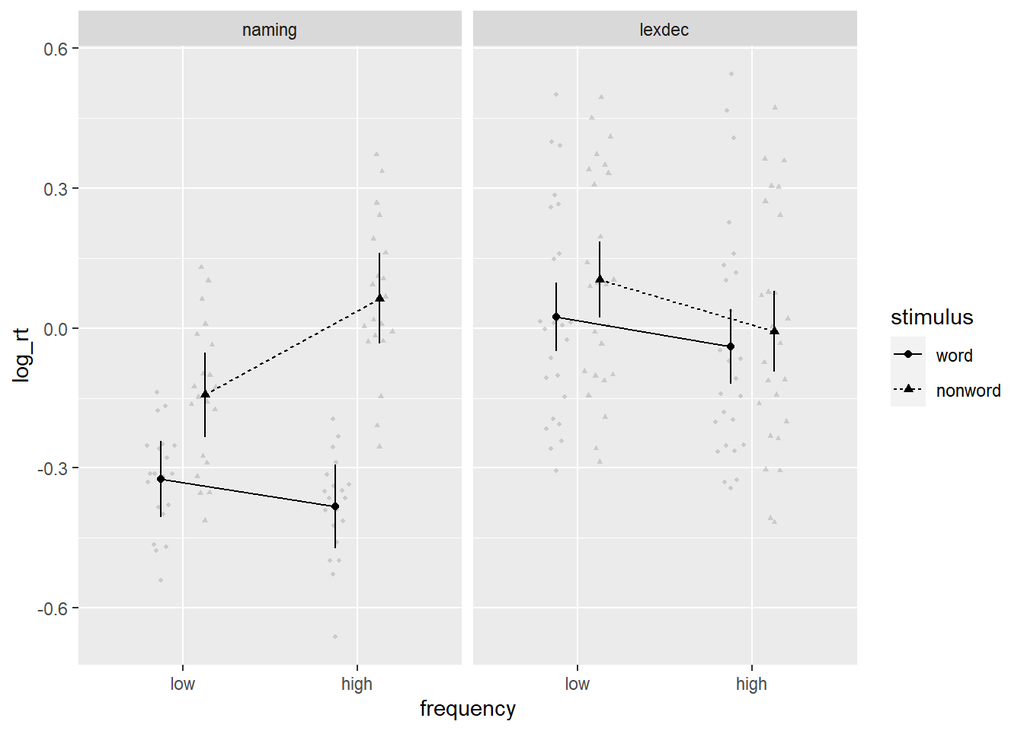

```r
afex_plot(m8s, x = "frequency", trace = "stimulus", panel = "task", id = "id",
          data_geom = geom_quasirandom,
          data_arg = list(
            dodge.width = 0.5,
            cex = 0.8,
            color = "darkgrey"))
```

## (2) 종속변수가 범주변수인 경우: 로짓혼합효과모형(logit mixed-effects models)

- `glmer()`
  - 기능: 종속변수가 이분 범주변수인 데이터에 대해 일반화선형혼합모형(generalized linear mixed models, GLMMs) 분석을 시행해줌.
  - 주요 논항: `family = binomial(link = "logit")`
- `mixed()`
  - 기능: 종속변수가 이분 범주변수인 데이터에 대해 일반화선형혼합모형 분석을 시행해줌.
  - 주요 논항
    - `family = binomial(link = "logit")`
    - `method = "LRT"`

```r
# 정답 여부를 범주변수(factor)로 바꾸기.
fhch_1 <- fhch2010 %>%
  as_tibble() %>%
  mutate(acc = case_when(correct == T ~ 1,
                         correct == F ~ 0)) %>%
  mutate(acc = as.factor(acc))

# lmerTest 패키지의 glmer() 함수를 사용하는 경우.
m8s_acc_glmer <- glmer(acc ~ task*stimulus*density*frequency +
                         (stimulus+frequency||id)+
                         (task|item), data = fhch_1,
                       family = binomial(link = "logit"), na.action = na.omit,
                       control = glmerControl(calc.derivs = FALSE, optCtrl = list(maxfun = 1e+06)))

# afex 패키지의 mixed() 함수를 사용하는 경우.
m8s_acc_mixed <- mixed(acc ~ task*stimulus*density*frequency +
                         (stimulus+frequency||id)+
                         (task|item), data = fhch_1,
                       family = binomial(link = "logit"), method = "LRT",
                       control = glmerControl(calc.derivs = FALSE, optCtrl = list(maxfun = 1e+06)))
```

# References

신정아. 2019. 혼합효과모형(Mixed-Effects Model)을 이용한 실험언어학 데이터 분석 방법 고찰: 자기조절읽기 실험 데이터를 중심으로. **영어학. 19**(1), 79-94.

이우열. 2000. 실험 데이터 분석을 위한 선형 혼합효과 모형. **한국심리학회지: 인지 및 생물, 32**(2), 197-211.

Barr, D. J., Levy, R., Scheepers, C., & Tily, H. J. (2013). Random effects structure for confirmatory hypothesis testing: Keep it maximal. *Journal of memory and language, 68*(3), 255-278.

Bates, D., Mächler, M., Bolker, B., & Walker, S. (2014). Fitting linear mixed-effects models using lme4. arXiv preprint arXiv:1406.5823. [링크](https://arxiv.org/pdf/1406.5823.pdf)

Brown, V. A. (2021). An introduction to linear mixed-effects modeling in R. *Advances in Methods and Practices in Psychological Science, 4*(1), 1-19.

Freeman, E., Heathcote, A., Chalmers, K., & Hockley, W. (2010). Item effects in recognition memory for words. *Journal of Memory and Language, 62*(1), 1-18.

Linck, J. A., & Cunnings, I. (2015). The utility and application of mixed‐effects models in second language research. * Language Learning, 65*(S1), 185-207.

Singmann, H. (2022). Mixed Model Reanalysis of RT data. Retrieved December 5, 2022 from https://bradleyboehmke.github.io/HOML/

Singmann, H., & Kellen, D. (2020). An Introduction to Mixed Psychology Models for Experimental Psychology. In D. H. Spieler & E. Schumacher (Eds.), *New Methods in Cognitive Psychology* (pp.4-31). New York, NY: Routledge.

Winter, B. (2013). Linear models and linear mixed effects models in R with linguistic applications. arXiv:1308.5499. [링크](http://arxiv.org/pdf/1308.5499.pdf)